# Group Lab 2

Jin Chang, Carmelita Deleon, Kevin Ho, Alisha Husain, Billy Wang

1/28/2019

For more information about the corresponding scripts please refer to this [link](https://github.com/jinc132/GEOG458_Group_Lab2/blob/master/Lab2.R)

## Introduction

This report focuses on the geographies of industry and employment at the tract level in *Bellevue, WA*, using data from the United States Census Bureau. Specifically, the 2015 main origin destination (OD) matrix, work area characteristic (WAC) data, and the residence area characteristic (RAC) data for the state of Washington were obtained from the US Census’ Longitudinal Employer-Household Dynamics. These data tell us the employment relationship between *“home”* and *“work”* census tracts, jobs of the people that live in a particular block, and jobs of the people that work in a particular block respectively. The data was obtained from an authoritative governmental source, though despite this, there are some general problems with Census data.

## Problems with Using Census Data

Some of the issues associated with Census Data include race categorization, microdata and statistical confidentiality, as well as interpolated values. Currently, the questions that the census asks about ethnic and racial origins follow a two step format; the first asks about race and the second about Hispanic origins. This is problematic because people who report Hispanic origins are assumed to be only Hispanic by the Census regardless of the person’s report on race. Much of the confusion surrounding identity has to do with the Census’ conceptualization of race and ethnicity and the limited choices that are presented [(McKenney & Bennett 1994; Alba 2018)](https://www.ncbi.nlm.nih.gov/pmc/articles/PMC1402238/). Microdata are records of information on individual respondents. Since the Census Bureau releases a fair amount of data to the public, including microdata, this raises issues of privacy, confidentiality, and protection against disclosure of individuals [(Hawala 2003; McCaa & Ruggles 2002)](http://users.pop.umn.edu/~rmccaa/census_microdata_revolution.pdf)  
Sources:  
https://www.census.gov/srd/sdc/microdataprotection.pdf  
Issues with Interpolated values  
https://www.ncbi.nlm.nih.gov/pmc/articles/PMC4624462/

## Why Bellevue?

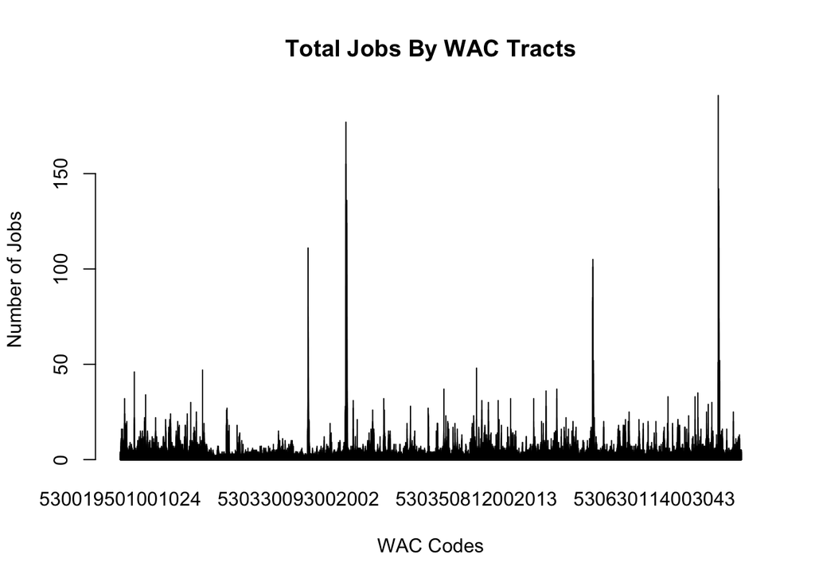

In our second portion, I decided to plot two overlapping maps of the same metric : salary earning bracket. The first histogram graphs job availability with salaries less than 1250/m with ones with salaries between 1250/m & 3333/m, with orange denoting the lower salary braket, and the yellow denoting the mid-tier salary bracket. It actually came to a suprise to me that there was such low availability for jobs in the lower salary paying range, as you can see with the high frequency occupancy of the orange and yellow bars. It seems that the covered work tracts in general do not have that many jobs paying less than 1250/m seeing as the orange tapers off before it reaches even the 20 value mark, and the yellow dissapears before hitting even 40, and both are concentrated between the 0-10 mark, denoting very low job availability.

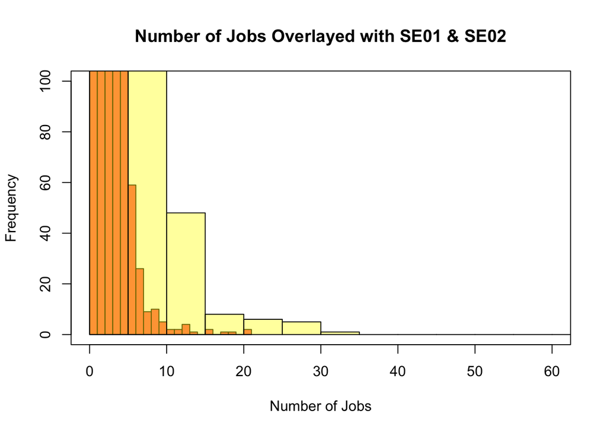

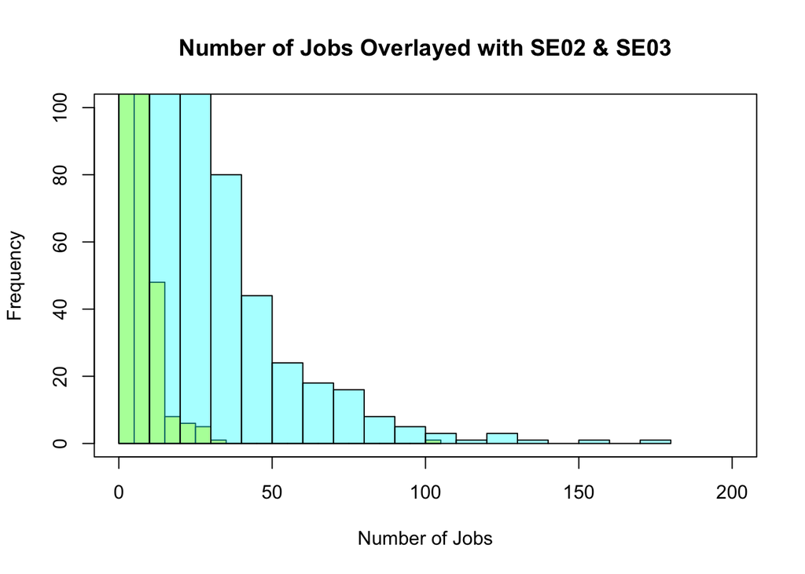

In the last graph, you see educational levels plotted through out the given work tracts and graphed along it’s corresponding number of jobs value. Not suprisingly, you see very rare sighting of edu1 points plotted along the graph, denoting that there are not many jobs for workers with less than a high school degree. You see a few sightings of available jobs for high school degrees and associate ones, which is a reassuring aspect, but the overwhelming display of the map is colored in purple (edu4). We see overall flat distributions throughout the plot, with high spikes in certain areas, reminiscent of the first graph, which showed total job availability. It cannot be directly stated the reason for these high spikes as they are statistical outliers and operate as such extremes, but can be assumed that they are potential large cities with higher populations, explaning their large job pool size and high job-educational necessity. With that being said, the entire purple filled map likely denotes that the number of jobs for workers with a bachelor’s degree or above is the most prominent and abundant. This is not to say that a worker with a bachelor’s degree or above will have readily access to a job, but that more likely that the firms hiring, all create positions that neccessitate a bachelor’s degree or above. This pairs well with the graph above, seeing that the given work tracts have larger amounts of available jobs the higher we go in salary pay, and all want workers with a educational level of bachelors or above. The pairing trend of high salary pay as well as large occupancy of higher educated workers means well for a growing and sustainable economy and workforce.

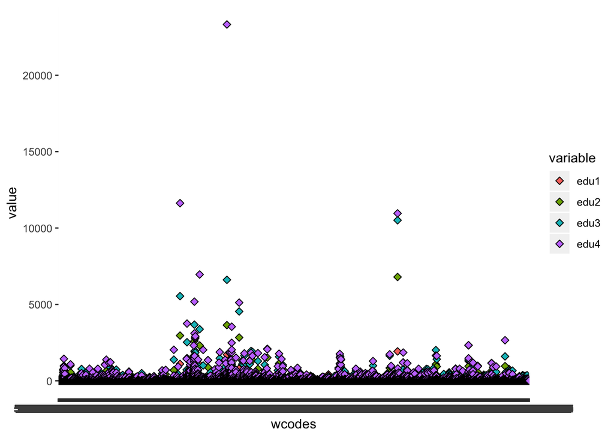

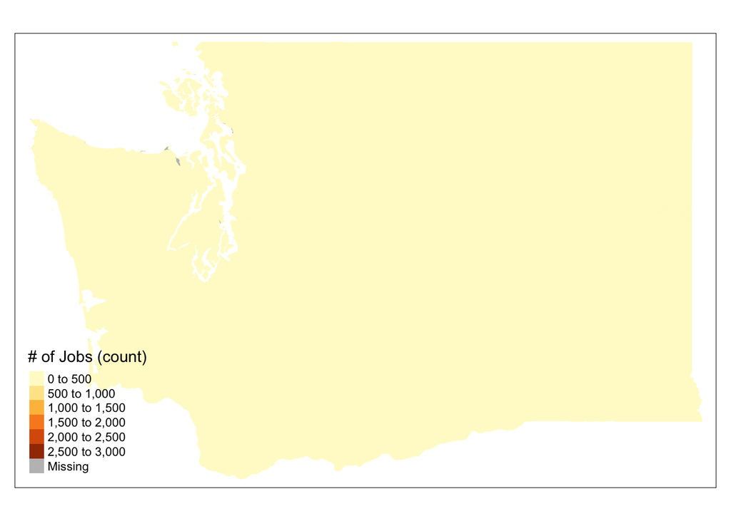

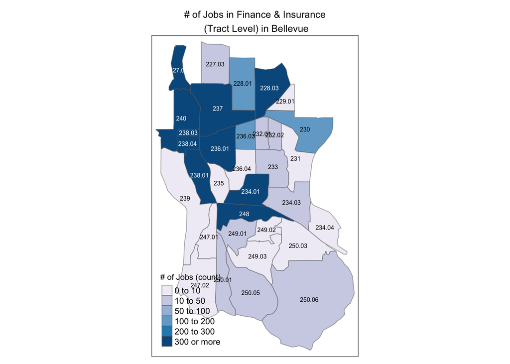

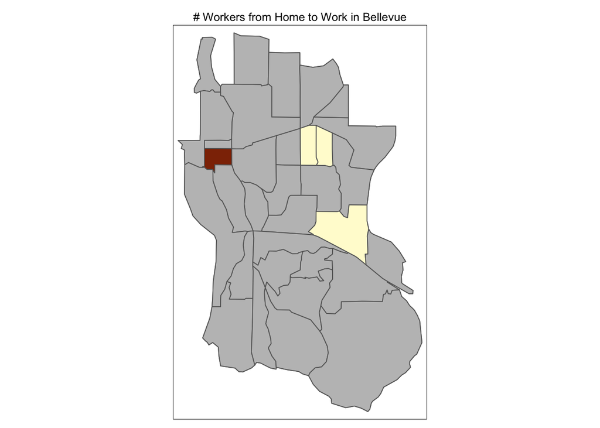

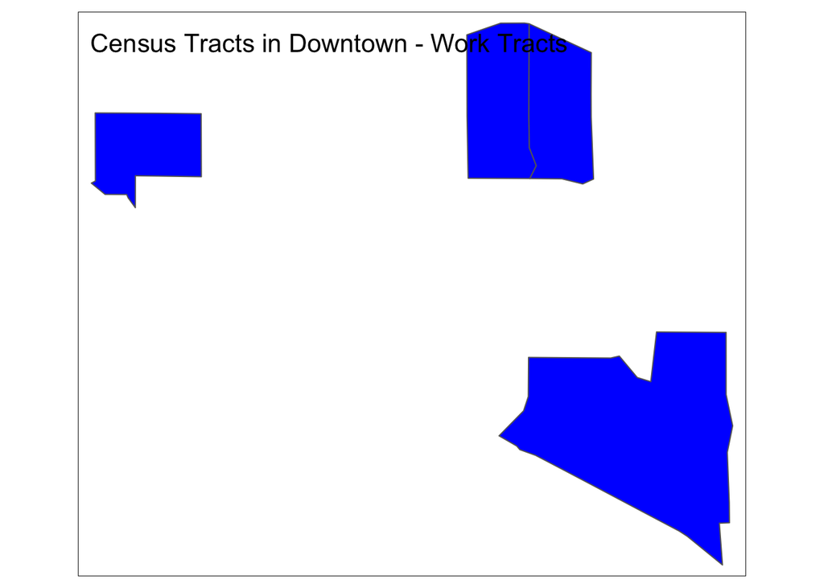

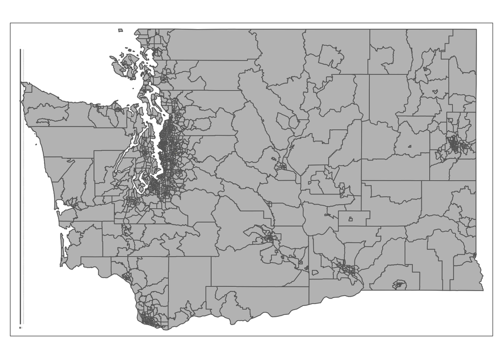

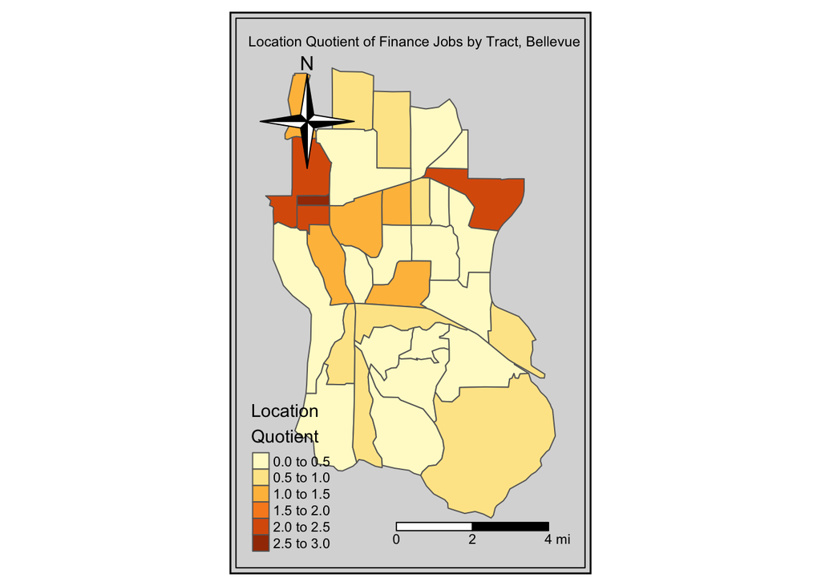